# **Python Fundamentals Project**

For the Data Science and Business Analytics Post-Graduate Program at the University of Texas in Austin

by Jacob Harper Fly  
August 17, 2025

**The Take Away:** As a physicist, my problem solving and analytical skills have made me into someone who loves debugging code - or rewriting code with more fundamental, mathematically universal functions so that the code can be properly diagnosed and trusted by operating with transparency. While much of the code displayed in this project may not be practical in most applications, it demonstrates my mastery of Python and ability to invent scripts to solve the problem at hand when the default approaches used by data scientists fail.

#### **Note From The Author**

Once again, this introduction to Python is so elementary, I doubt my reader will get much substance out of my ability to perform mere data analytics, so I used it as an opportunity to also make some art in the hopes that this otherwise elementary first project can at least carry some entertainment value.

For in anything I write for the public, there is some art or there is nothingness. And what is it to exist if I do not write as I will? I don't know, so I choose art.

## **Preface:** The What, The Who, and The Whom

### The Context

The number of restaurants in **New York** is increasing day by day. Lots of students and busy professionals rely on those restaurants due to **their hectic lifestyles**. Online food delivery service is a great option for them. It provides them with good food from their favorite restaurants. A food aggregator company FoodHub offers access to multiple restaurants through a single smartphone app.

The app allows the restaurants to receive a direct online order from a customer. The app assigns a **delivery person from the company** to pick up the order after it is confirmed by the restaurant. The delivery person then uses the map to reach the restaurant and waits for the food package. Once the food package is handed over to the delivery person, he/she confirms the pick-up in the app and travels to the customer's location to deliver the food. The delivery person confirms the drop-off in the app after delivering the food package to the customer. The customer can rate the order in the app. The food aggregator earns money by collecting a fixed margin of the delivery order from the restaurants.

## Objective

The food aggregator company has stored the data of the different orders made by the registered customers in their online portal. They want to analyze the data to get a fair idea about the demand of different restaurants which will help them in enhancing their customer experience. As a Data Scientist, I will be answering some of the key questions that need to be answered, performing data analysis to improve the business.  
Essentially, any insight that would make the ratings go up or increase the income amount of money spent at the restaurants.

## Data Description

I have been provided with some data related to a food order, and the detailed data dictionary is given below.

### **Data Dictionary**

- Order ID: Unique ID of the order
- Customer ID: ID of the customer who ordered the food
- Restaurant Name: Name of the restaurant
- Cuisine Type: Cuisine ordered by the customer
- Cost Of The Order: Cost of the order
- Day Of The Week: Indicates whether the order is placed on a weekday or weekend (The weekday is from Monday to Friday and the weekend is Saturday and Sunday)
- Rating: Rating given by the customer out of 5
- Food Preparation Time: Time (in minutes) taken by the restaurant to prepare the food. This is calculated by taking the difference between the timestamps of the restaurant's order confirmation and the delivery person's pick-up confirmation.
- Delivery Time: Time (in minutes) taken by the delivery person to deliver the food package. This is calculated by taking the difference between the timestamps of the delivery person's pick-up confirmation and drop-off information

## **Forward:** Importing The Required Libraries

```python
!pip install numpy==1.25.2 pandas==1.5.3 matplotlib==3.7.1 seaborn==0.13.1 -q --user
# If it appears as though an error has occurred, try running it again.
```

[output not shown]

First, I'll import libraries for data manipulation

```python
import numpy as np
import pandas as pd
```

Due to issues with the 'notebook's environment,' plotly can occassionaly quit working; therefore, I have installed this switch

Then, import libraries for data visualization. *For the purposes of this project, I will be using Seaborn and Plotly - and Matplotlib is referred to by Seaborn, so it too must be imported.*

```python
import matplotlib.pyplot as plt
import seaborn as sns
try:
    import plotly.express as px
except:
    on == False
```

And finally, I'll load in the data.  
(I know, it isn't in a folder, but I like to make copies of my files often and... well, I just don't have a lot going on in my Google Drive... yet!)

### **Introduction:** The Structure Of The Data

First things first, I should see if it has loaded properly.

```python
from google.colab import drive
drive.mount('/content/drive')
order = pd.read_csv('/content/drive/MyDrive/Data Analytics/Python/foodhub_order.csv')
```

```python
order.head()
```

|  | order_id | customer_id | restaurant_name | cuisine_type | cost_of_the_order | day_of_the_week | rating | food_preparation_time | delivery_time |
| --- | --- | --- | --- | --- | --- | --- | --- | --- | --- |
| 0 | 1477147 | 337525 | Hangawi | Korean | 30.75 | Weekend | Not given | 25 | 20 |
| 1 | 1477685 | 358141 | Blue Ribbon Sushi Izakaya | Japanese | 12.08 | Weekend | Not given | 25 | 23 |
| 2 | 1477070 | 66393 | Cafe Habana | Mexican | 12.23 | Weekday | 5 | 23 | 28 |
| 3 | 1477334 | 106968 | Blue Ribbon Fried Chicken | American | 29.20 | Weekend | 3 | 25 | 15 |
| 4 | 1478249 | 76942 | Dirty Bird to Go | American | 11.59 | Weekday | 4 | 25 | 24 |

And it looks as expected; huzzah!  
However...  
These headings aren't very flattering. Let's fix that:

```python
order = order.rename(columns={'order_id':'Order ID','customer_id':'Customer ID','restaurant_name':'Restaurant Name','cuisine_type':'Cuisine Type','cost_of_the_order':'Cost Of The Order','day_of_the_week':'Day Of The Week','rating':'Rating','food_preparation_time':'Food Preparation Time','delivery_time':'Delivery Time'})
order.head()
```

|  | Order ID | Customer ID | Restaurant Name | Cuisine Type | Cost Of The Order | Day Of The Week | Rating | Food Preparation Time | Delivery Time |
| --- | --- | --- | --- | --- | --- | --- | --- | --- | --- |
| 0 | 1477147 | 337525 | Hangawi | Korean | 30.75 | Weekend | Not given | 25 | 20 |
| 1 | 1477685 | 358141 | Blue Ribbon Sushi Izakaya | Japanese | 12.08 | Weekend | Not given | 25 | 23 |
| 2 | 1477070 | 66393 | Cafe Habana | Mexican | 12.23 | Weekday | 5 | 23 | 28 |
| 3 | 1477334 | 106968 | Blue Ribbon Fried Chicken | American | 29.20 | Weekend | 3 | 25 | 15 |
| 4 | 1478249 | 76942 | Dirty Bird to Go | American | 11.59 | Weekday | 4 | 25 | 24 |

That's much better!  
Thus, with data in hand, we are ready to depart on a journey to a land that lies behind reality: the land of imagination and it's crystalized manifestations of the data that that reality so soon left behind.

# **Prologue:** An Unperculiar Sunday Tea

As I sit here - tea in hand, the sun in the windows, a quiet clock bellowing through the halls that have become riddled by the beat of its own echo, mocking the silence - my mind fills with the tune that only the brain can sing. I swim in the sound of these thoughts which cry: what is it that I don't know.  
*But it is hardly the time for drowning.*

## Flashback To A Simpler Time

It was hot, but raining. Was I lost? Maybe, but lost from where? I could see the sky touch the horizon, yet I stayed. Here, I had no mind of the brain in the rain: summer was always more beautful in the rain.

### What am I out here hunting for:

- Increase spending
- Higher ratings
- Returning customers
- Successful restaurants
- Successful forms of food to advertise

### **EXT. POOL - DAY**

**JO:** Woah, woah, hold your horses, partner. Who do you think you are, assuming there isn't any sort of false causality between the successful forms of the food and the restaurants themselves?

**JACK:** Well, Plato would argue that forms are the essence of all things. I mean, we can't just completely rely on the numbers if we ever want to get to prescriptive data analytics. And it's not like numbers are the essence of all things. What do you think this is? Pre-classical Italy, Pythagoras?

**JO:** You did not just call me Pythagoras.

**JACK:** That's exactly the kind of thing that Pythagoras would say.

**JO:** I don't have to put up with this attitude. I went to Juiliard.

**JACK:** "Oh, I'm Pythagoras, and I'm so special. I know how to form round peg to round hole associations and everything. I learned that at Juiliard!" That's you. That's how you sound right now.

**JO:** Are you done now?

**JACK:** Sorry.

**JO:** Anyways, even under that Platonic idealism, you contradict yourself by suggesting that knowing the successful restaurants is significant to the findings of the study.

**JACK:** *(putting his sunglasses on and returning to his relaxed lounging position,)*  
It certainly can't hurt to have more informaton.

**JO:** Certainly? I can't believe the words that I am hearing come out of your mouth.

**JACK:** ...  
*(starring at Jo, Jack takes a sip from the crazy straw in his coconut.)*

**JO:** I don't understand you. You go full Plato-mode on me just for asking about the potential for a false correlation, yet you're just riding the information current wherever it takes you.

**JO (CONT'D):***(Getting up to leave, then stopping himself and turning around to get another word in,)*  
Oh yeah, and another thing, you shouldn't be one to talk about Yale like that when you clearly got your own insights and strategies from your Post-Grad Data Analytics certificate program. Yeah! Don't think I didn't notice that little bit about "hunting for returning customers" bit from above. You got that from the Pre-Work modules, but for all you know, that little rule they taught you in your intro-to-data class may not apply to this. This is the real world.

*(The thoughts in which I swim die down with less left to give than the ongoing sprinkle.)*

**Jack:***(Throwing out the little umbrella from his coconut drink and getting up.)*  
But that is what experimentation and time are for. We have to know how things are before we can compare any changes to the system to this data, despite how it is currently controlled, for it acts as a control group.

**JO:** Where are you going?

**JACK:** Out.

**JO:** What? You can't be the one to walk out of this complete unnecessary and awkward Socratic dialogue part of a Data Analytics HTML file! I'm the one who made this a dialogue! I should be the one to get the iconic last line! I'm the clever one! ... Fine! Go! See if I care! I still have the spotlight, so I'm going to have the last word whether you like it or not!

**...**

JO (CONT'D): Road House.

End Of Play

## Film Noir Interlude

From all my years as a detective, if I had to say one thing about mysteries, it is that they are mysterious. I couldn't let that get to me. I had to crack the case.

### Unanswered Questions:

- If there may exist some false causality, which restaurants are doing well despite not recieving some key real-estate within the single app's algorithm?
- Is the paradigm of awarding ratings a product of some essential and useful data, or is the essence of the paradigm to have the paradigm itself - that is, as a form of being-for-itelf where it's existence precedes it's essence while its essence does not persist (Sartre, "Being And Nothingness")?
- Likewise, can users be classified such that those classes hold any formal reality? Classes such as
  - The Cateror (spending a lot but rarely)
  - The Hurricane (spending a lot, a lot)
  - The Majesty (spending a little, often)
  - The Sampler (spent a little a time or two)
- If such classes have some formal reality, how is that existence reflected by the system of meaning embewed into the significance of their various forms of rating?
- Is the essence of the paradigm assiociate with the subjects membership within a community - given that community is essential to such a "language game," as Wittgenstein may have put it.

### The End?

Well, the way to get answers to all these questions is to stop the storytelling and get into the coding of data, and so, without further ado, let us begin.

# **ACT I:** Setting The Stage

First, we determine what tools will be needed in order to properly loop through all of the data, waiting for someone in the crowd to finally see their data points, to really see them and all they have to give to this place, if only they were cast.  
*For the whole world is a stage, and every one deserves to have a part in it. **Every one.***

### **Question 1:**

How many rows and columns are present in the data?

```python
rown, coln = order.shape
print("There are",rown,"rows, and there are",coln,"columns.")
```

```
There are 1898 rows, and there are 9 columns.
```

#### Observations:

The most apparent observation is that there is a lot of data here (that is, with this having 1898 rows and 9 columns).

### **Question 2:**

What are the datatypes of the different columns in the dataset?

First, I'm going to create a function to translate the language of the code's types into English:

## The Translator

```python
def translator(what):
  if str(what) == "int64":
    it = "Integer"
  elif str(what) == "float64":
    it = "Float"
  elif str(what) == "bool":
    it = "Boolean"
  elif str(what) == "datetime64":
    it = "Date"
  else:
    it = "Object"
  return it
```

Now, let's put the translator in action with the unique data types found in the data!

```python
types = order.dtypes.unique()
print("The data types in the data set include")
i = 0
while i < len(types):
  print("  ",i+1,") ",translator(types[i])," (",types[i],")",sep="")
  i += 1
```

```
The data types in the data set include
  1) Integer (int64)
  2) Object (object)
  3) Float (float64)
```

And finally, let's get more specific and see if the data type of the data in the column is what one might expect.

```python
def toy_story(data):
  print("The data type contained by the different columns are")
  i = 0
  while i < len(data.columns):
    print("  ",i+1,") ",data.columns[i],"."*(23-len(data.columns[i]))," ",translator(data[data.columns[i]].dtype),sep="")
    i += 1
toy_story(order)
```

```
The data type contained by the different columns are
  1) Order ID............... Integer
  2) Customer ID............ Integer
  3) Restaurant Name........ Object
  4) Cuisine Type........... Object
  5) Cost Of The Order...... Float
  6) Day Of The Week........ Object
  7) Rating................. Object
  8) Food Preparation Time.. Integer
  9) Delivery Time.......... Integer
```

#### Observations:

- While this isn't too surprising, it seems as though it took the Identities of beings in the data to be integers even though they contain no information regarding the sum of some fundamental unit of measurement.
- Moreover, the rating is seen as an object despite it playing the role of some quantised figure of some system of measurements projected by some subject onto their objectification of the system itself - which is how I imagine Simone De Beauvoir might have put it. Thus, while ratings very well can be treated as an "Object," the scientist must recognize the potential of existence of what precedes it while also recognizing - while also *respecting* - the paradigm essential to any such object itself. Thus, "Ratings" should be of the data type "Float."
- Everything else about the data types of the data in the columns is not too surprising; however, it is ironic that the "Cost Of The Order" data is a "Float" and the two columns containing "time" data are of "Integer" type data, but this seems rather superfluous given that to record any such value is merely symbolic to the purpose of non-judicial data analysis - however, I won't begin explaining Anaximander's metaphysics due to the relatively tangential nature that any such arguements would serve to an already superfluous concern for the data.

### Question: Is there are significance to the order ID numbers, or do they just act as a very impractical index from some former dataset? And what about the customer ID numbers? Am I just spinning my tires?

```python
rown - len(order['Order ID'].unique())
```

```
0
```

```python
rown - len(order['Customer ID'].unique())
```

```
698
```

#### Observation:

The Order ID column seems insignificant and can be dropped (which is actually kind of a relief because I would worry that there was some glitch in the system if I saw a single order logged more than once).

However, the customer ID numbers seem quite significant with 698 of the orders being from returning profiles.

```python
original = order.copy()
order = order.drop(['Order ID'],axis=1)
rown, coln = order.shape
order.head()
```

|  | Customer ID | Restaurant Name | Cuisine Type | Cost Of The Order | Day Of The Week | Rating | Food Preparation Time | Delivery Time |
| --- | --- | --- | --- | --- | --- | --- | --- | --- |
| 0 | 337525 | Hangawi | Korean | 30.75 | Weekend | Not given | 25 | 20 |
| 1 | 358141 | Blue Ribbon Sushi Izakaya | Japanese | 12.08 | Weekend | Not given | 25 | 23 |
| 2 | 66393 | Cafe Habana | Mexican | 12.23 | Weekday | 5 | 23 | 28 |
| 3 | 106968 | Blue Ribbon Fried Chicken | American | 29.20 | Weekend | 3 | 25 | 15 |
| 4 | 76942 | Dirty Bird to Go | American | 11.59 | Weekday | 4 | 25 | 24 |

```python
toy_story(order)
```

```
The data type contained by the different columns are
  1) Customer ID............ Integer
  2) Restaurant Name........ Object
  3) Cuisine Type........... Object
  4) Cost Of The Order...... Float
  5) Day Of The Week........ Object
  6) Rating................. Object
  7) Food Preparation Time.. Integer
  8) Delivery Time.......... Integer
```

Now that the data is sorted, there seems to be no reason not to consider the data in more maliable terms. To deny such would be to deny the fundamental nature of data, and I have already discussed the beauty of considering the recognizing the existence of other forms of data. However, for the purposes of this assignement, I will change the types of the data into either an object to be categorized or a float with which to manipulate its values.

### **Question 3:**

Are there any missing values in the data?

## Ghostbusters 3

First, I'll build a proton pack with which to detect any missing values in the columns.

```python
def proton_pack(what,where):
  y = 0
  while y < rown:
    i = order.iloc[y, what]
    if i == "" or i == "Not given":
      where[order.columns[what]] += 1
    else:
      0
    y += 1
```

And now, to put it in action! What I have done is created a dictionary that will carry the sum of encounters that the proton pack (above) has had while traversing the column.

I have this occur within a loop so that this will occur for each column.

```python
def ghostbusters(data):
  x = 0;
  while x < coln:
    missing = {}
    missing[data.columns[x]] = 0
    proton_pack(x,missing)
    x += 1
    print(str(missing.keys()).replace("dict_keys([","").replace('])',''),"."*(40-len(str(missing.keys()))),str(missing.values()).replace("dict_values([","").replace('])',''))
ghostbusters(order)
```

```
'Customer ID' .............. 0
'Restaurant Name' .......... 0
'Cuisine Type' ............. 0
'Cost Of The Order' ........ 0
'Day Of The Week' .......... 0
'Rating' ................... 736
'Food Preparation Time' .... 0
'Delivery Time' ............ 0
```

## Citizen Kane

It isn't too surprising given that the app can automatically collect all of the data without any manual efforts asked of the consumer, and such may point to a greater fact regarding the ambiguity of its significance despite how significant it is imagined to have by the consumer willing to engage in such a manual activity.

But for now, they should be treated.

Only, how?

Well, we must turn back to the beginning of this "Citizen Kane" section, back to where it all started, all to reveal the dualistic systems of meaning that can be all but overlooked until it's too late to remember what it was all for.

### The meaning of the who to us whom we depend

I will create two data frames. The first data frame will be used to explore the values associated with the people being served, and the latter dataset will be to explore the values associated with the business.

The businesses can be understood with averaged data because this will allow the other values to be more fairly assessed, and assessing the restaurants with hundreds of systems of meaning all reduced to the same five symbols is preposterous.

When exploring the systems of meaning attributed to the ratings themselves, my primary interests lie in the differences between those who assign rating and those who don't, so this too will require two data sets

This puts the total number of datasets required up to a total of 3:

- Data of with average ratings
- Data of whether a rating was or wasn't given
- Data of ratings redacted

The first two data frames in this list can be derived from a single data frame as yin and yang can derived from our comprehending of the universe in light of this universe which presents itself as the existence of what is and what is not.

However, the last data frame can be cut up in a great myriad of ways, such that while it appears as though there are really two data frames that I need to play the part of these three organizations of data, out of these three are all the myriad data frames to be played with.

### "Rosebud"

First, I will create a function that will determine what to do with the 'Not given' "Ratings" entries.

The function below will take the data frame (what), the row to be changed (paper), the row to index by (home), and the variable to be replaced (mark). Then, it will return a dictionary of unique home values as keys and the average paper value of non mark-ed values as values.

```python
def rosebud(what,press,home,mark):
  i = 0; dic = {}; snow = 0; momenta = 0;
  love = order.columns.get_loc(home)
  paper = order.columns.get_loc(press)
  snow = what[home].unique()
  while i < len(snow):
    momenta = snow[i]
    j = 0; how = 0; why = 0;
    rowm, colm = what.shape
    while j < rowm:
      if what.iloc[j,love] == momenta and str(order.iloc[j,paper]) != str(mark):
        if mark == 'Mr. Thatcher':
          how += order.iloc[j,paper]
        else:
          how += int(order.iloc[j,paper])
        why += 1
      else:
        0
      j += 1
    if why == 0:
      dic[momenta] = np.nan
    else:
      dic[momenta] = how/why
    i += 1
  return dic
```

And now, let's give that bad boy a spin!

```python
average_ratings_of_restaurants = rosebud(order,'Rating','Restaurant Name','Not given')
print(str(average_ratings_of_restaurants)[:150],'...')
```

```
{'Hangawi': nan, 'Blue Ribbon Sushi Izakaya': 4.333333333333333, 'Cafe Habana': 4.2727272727272725, 'Blue Ribbon Fried Chicken': 4.328125, 'Dirty Bird ...
```

Perhaps I should look at the mean. For while there are a great number of restaurants that may have almost no reviews which act as outliers, the missing values that I am treating are for restaurants with no ratings, and as such, they are subject to just as much rating volatility.

```python
df = average_ratings_of_restaurants.copy()
df = pd.DataFrame(list(average_ratings_of_restaurants.items()),columns = ['Restaurant Name','Rating'])
df = df.dropna()
the_new_pi = df['Rating'].mean()
print("The average score that a restaurant gets is", the_new_pi)
```

```
The average score that a restaurant gets is 4.39780720150067
```

I'm going to come back to this value, but I can't bring myself to blindly trust it. Instead, I will get right into adding some more columns.

# **Act II:** The Variables

In this act, I am going to spend most of the space defining new columns, so if the definition of a column gets lost, know that the table of contents should take you here.

For the sake of space, I will label the column and attach a short description, write the code below, and repeat.

## New Column Dictionary

### 8. Rated

If the restaurant had been rated, this value is True.

```python
i = 0
while i < rown:
  if str(order.iloc[i,5]) == 'Not given':
    order.loc[i,'Rated'] = False
  else:
    order.loc[i,'Rated'] = True
  i += 1
order.head()
```

|  | Customer ID | Restaurant Name | Cuisine Type | Cost Of The Order | Day Of The Week | Rating | Food Preparation Time | Delivery Time | Rated |
| --- | --- | --- | --- | --- | --- | --- | --- | --- | --- |
| 0 | 337525 | Hangawi | Korean | 30.75 | Weekend | Not given | 25 | 20 | False |
| 1 | 358141 | Blue Ribbon Sushi Izakaya | Japanese | 12.08 | Weekend | Not given | 25 | 23 | False |
| 2 | 66393 | Cafe Habana | Mexican | 12.23 | Weekday | 5 | 23 | 28 | True |
| 3 | 106968 | Blue Ribbon Fried Chicken | American | 29.20 | Weekend | 3 | 25 | 15 | True |
| 4 | 76942 | Dirty Bird to Go | American | 11.59 | Weekday | 4 | 25 | 24 | True |

### 9. Total Delivery Time

The sum of Delivery Time and Preparation Time.

```python
i = 0
while i < rown:
  order.loc[i,'Total Time'] = order.loc[i,'Delivery Time'] + order.loc[i,'Food Preparation Time']
  i += 1
order.head()
```

|  | Customer ID | Restaurant Name | Cuisine Type | Cost Of The Order | Day Of The Week | Rating | Food Preparation Time | Delivery Time | Rated | Total Time |
| --- | --- | --- | --- | --- | --- | --- | --- | --- | --- | --- |
| 0 | 337525 | Hangawi | Korean | 30.75 | Weekend | Not given | 25 | 20 | False | 45.0 |
| 1 | 358141 | Blue Ribbon Sushi Izakaya | Japanese | 12.08 | Weekend | Not given | 25 | 23 | False | 48.0 |
| 2 | 66393 | Cafe Habana | Mexican | 12.23 | Weekday | 5 | 23 | 28 | True | 51.0 |
| 3 | 106968 | Blue Ribbon Fried Chicken | American | 29.20 | Weekend | 3 | 25 | 15 | True | 40.0 |
| 4 | 76942 | Dirty Bird to Go | American | 11.59 | Weekday | 4 | 25 | 24 | True | 49.0 |

## Gravity (Function)

This function takes in a column of objects, then produces a dictionary of the frequency of each unique value. The dictionary value of the column is then assigned to a new column in each row where that object appears.

**The following functions do just that.**

```python
def gravity(inertia):
  i = 0; j = 0; dic = {};
  k = order.columns.get_loc(inertia)
  mass = inertia.split(' ')[0]
  while i < rown:
    if order.iloc[i,k] in dic:
      dic[order.iloc[i,k]] += 1
    else:
      dic[order.iloc[i,k]] = 1
    i += 1
  while j < rown:
    order.loc[j,(mass+' Regularity')] = dic[order.iloc[j,k]]
    j += 1
  return order.head()
```

### 10. Customer Regularity

This column, for example, holds the value associated with the number of times that the Customer ID has appeared in this particular data set.

```python
gravity('Customer ID')
```

|  | Customer ID | Restaurant Name | Cuisine Type | Cost Of The Order | Day Of The Week | Rating | Food Preparation Time | Delivery Time | Rated | Total Time | Customer Regularity |
| --- | --- | --- | --- | --- | --- | --- | --- | --- | --- | --- | --- |
| 0 | 337525 | Hangawi | Korean | 30.75 | Weekend | Not given | 25 | 20 | False | 45.0 | 2.0 |
| 1 | 358141 | Blue Ribbon Sushi Izakaya | Japanese | 12.08 | Weekend | Not given | 25 | 23 | False | 48.0 | 1.0 |
| 2 | 66393 | Cafe Habana | Mexican | 12.23 | Weekday | 5 | 23 | 28 | True | 51.0 | 1.0 |
| 3 | 106968 | Blue Ribbon Fried Chicken | American | 29.20 | Weekend | 3 | 25 | 15 | True | 40.0 | 2.0 |
| 4 | 76942 | Dirty Bird to Go | American | 11.59 | Weekday | 4 | 25 | 24 | True | 49.0 | 3.0 |

### 11. Cuisine Regularity

```python
gravity('Cuisine Type')
```

|  | Customer ID | Restaurant Name | Cuisine Type | Cost Of The Order | Day Of The Week | Rating | Food Preparation Time | Delivery Time | Rated | Total Time | Customer Regularity | Cuisine Regularity |
| --- | --- | --- | --- | --- | --- | --- | --- | --- | --- | --- | --- | --- |
| 0 | 337525 | Hangawi | Korean | 30.75 | Weekend | Not given | 25 | 20 | False | 45.0 | 2.0 | 13.0 |
| 1 | 358141 | Blue Ribbon Sushi Izakaya | Japanese | 12.08 | Weekend | Not given | 25 | 23 | False | 48.0 | 1.0 | 470.0 |
| 2 | 66393 | Cafe Habana | Mexican | 12.23 | Weekday | 5 | 23 | 28 | True | 51.0 | 1.0 | 77.0 |
| 3 | 106968 | Blue Ribbon Fried Chicken | American | 29.20 | Weekend | 3 | 25 | 15 | True | 40.0 | 2.0 | 584.0 |
| 4 | 76942 | Dirty Bird to Go | American | 11.59 | Weekday | 4 | 25 | 24 | True | 49.0 | 3.0 | 584.0 |

### 12. Restaurant Regularity

```python
gravity('Restaurant Name')
```

|  | Customer ID | Restaurant Name | Cuisine Type | Cost Of The Order | Day Of The Week | Rating | Food Preparation Time | Delivery Time | Rated | Total Time | Customer Regularity | Cuisine Regularity | Restaurant Regularity |
| --- | --- | --- | --- | --- | --- | --- | --- | --- | --- | --- | --- | --- | --- |
| 0 | 337525 | Hangawi | Korean | 30.75 | Weekend | Not given | 25 | 20 | False | 45.0 | 2.0 | 13.0 | 2.0 |
| 1 | 358141 | Blue Ribbon Sushi Izakaya | Japanese | 12.08 | Weekend | Not given | 25 | 23 | False | 48.0 | 1.0 | 470.0 | 29.0 |
| 2 | 66393 | Cafe Habana | Mexican | 12.23 | Weekday | 5 | 23 | 28 | True | 51.0 | 1.0 | 77.0 | 16.0 |
| 3 | 106968 | Blue Ribbon Fried Chicken | American | 29.20 | Weekend | 3 | 25 | 15 | True | 40.0 | 2.0 | 584.0 | 96.0 |
| 4 | 76942 | Dirty Bird to Go | American | 11.59 | Weekday | 4 | 25 | 24 | True | 49.0 | 3.0 | 584.0 | 4.0 |

## Weak (function)

This function produces a column that works with dictionary values as well; however, this time, I will be looking at the average amount of money spent on the Customer ID's account and at the average time spent by a restaurant (either due to their prep-time or due to their geography, for the customer doesn't just stop being hungry whenever it is no longer the kitchen's fault for the delay).

The data required for the function is:

- **the data frame** (electron, like that which give the nucleus its structure within observable systems),
- **the column to be averaged** (the neutron, like that capable of decaying by the weak force),
- **the column to be indexed by** and to have it's uniqued values assigned some average (p, as in that ambiguously referrencing either the momentum or the proton dislodged from "the atom" while maintaining the most fundamental principles of the classical model: the second law of Physics), and
- **the new name of the function** (particle, like that name attributed to the decay of Democrates' philosophy).

```python
def weak(electron,neutron,p,particle):
  mine = rosebud(electron,neutron,p,'Mr. Thatcher')
  j = 0; rown,coln = electron.shape;
  while j < rown:
    order.loc[j,(particle)] = mine[order.loc[j,p]]
    j += 1
  return order.head()
```

### 13. Average Bill

This column contains the average amount spent with the customer ID.

```python
weak(order,'Cost Of The Order','Customer ID','Average Bill')
```

|  | Customer ID | Restaurant Name | Cuisine Type | Cost Of The Order | Day Of The Week | Rating | Food Preparation Time | Delivery Time | Rated | Total Time | Customer Regularity | Cuisine Regularity | Restaurant Regularity | Average Bill |
| --- | --- | --- | --- | --- | --- | --- | --- | --- | --- | --- | --- | --- | --- | --- |
| 0 | 337525 | Hangawi | Korean | 30.75 | Weekend | Not given | 25 | 20 | False | 45.0 | 2.0 | 13.0 | 2.0 | 31.985 |
| 1 | 358141 | Blue Ribbon Sushi Izakaya | Japanese | 12.08 | Weekend | Not given | 25 | 23 | False | 48.0 | 1.0 | 470.0 | 29.0 | 12.080 |
| 2 | 66393 | Cafe Habana | Mexican | 12.23 | Weekday | 5 | 23 | 28 | True | 51.0 | 1.0 | 77.0 | 16.0 | 12.230 |
| 3 | 106968 | Blue Ribbon Fried Chicken | American | 29.20 | Weekend | 3 | 25 | 15 | True | 40.0 | 2.0 | 584.0 | 96.0 | 18.990 |
| 4 | 76942 | Dirty Bird to Go | American | 11.59 | Weekday | 4 | 25 | 24 | True | 49.0 | 3.0 | 584.0 | 4.0 | 17.670 |

### 14. Average Restaurant Time

Average time it takes a customer to get food from the restaurant.

```python
weak(order,'Total Time','Restaurant Name','Average Restaurant Time')
```

|  | Customer ID | Restaurant Name | Cuisine Type | Cost Of The Order | Day Of The Week | Rating | Food Preparation Time | Delivery Time | Rated | Total Time | Customer Regularity | Cuisine Regularity | Restaurant Regularity | Average Bill | Average Restaurant Time |
| --- | --- | --- | --- | --- | --- | --- | --- | --- | --- | --- | --- | --- | --- | --- | --- |
| 0 | 337525 | Hangawi | Korean | 30.75 | Weekend | Not given | 25 | 20 | False | 45.0 | 2.0 | 13.0 | 2.0 | 31.985 | 44.000000 |
| 1 | 358141 | Blue Ribbon Sushi Izakaya | Japanese | 12.08 | Weekend | Not given | 25 | 23 | False | 48.0 | 1.0 | 470.0 | 29.0 | 12.080 | 52.206897 |
| 2 | 66393 | Cafe Habana | Mexican | 12.23 | Weekday | 5 | 23 | 28 | True | 51.0 | 1.0 | 77.0 | 16.0 | 12.230 | 52.312500 |
| 3 | 106968 | Blue Ribbon Fried Chicken | American | 29.20 | Weekend | 3 | 25 | 15 | True | 40.0 | 2.0 | 584.0 | 96.0 | 18.990 | 51.343750 |
| 4 | 76942 | Dirty Bird to Go | American | 11.59 | Weekday | 4 | 25 | 24 | True | 49.0 | 3.0 | 584.0 | 4.0 | 17.670 | 48.000000 |

Piece of cake! But how might I fill in the values for the restaurants that have never recieved a rating?

Let's explore what matters?

```python
order.groupby('Rated')['Total Time'].describe()
```

| Rated | count | mean | std | min | 25% | 50% | 75% | max |
| --- | --- | --- | --- | --- | --- | --- | --- | --- |
| False | 736.0 | 51.531250 | 6.941278 | 35.0 | 47.0 | 52.0 | 56.0 | 68.0 |
| True | 1162.0 | 51.535284 | 6.767522 | 35.0 | 47.0 | 51.0 | 56.0 | 68.0 |

```python
order.groupby('Rated')['Average Bill'].describe()
```

| Rated | count | mean | std | min | 25% | 50% | 75% | max |
| --- | --- | --- | --- | --- | --- | --- | --- | --- |
| False | 736.0 | 16.20218 | 5.813746 | 5.05 | 12.1800 | 15.478889 | 19.412500 | 33.03 |
| True | 1162.0 | 16.68676 | 5.946161 | 4.75 | 12.5025 | 15.840000 | 20.338333 | 33.32 |

The amount of time and money required to get the food did not determine whether the customer left a rating.

```python
order.groupby('Rated')['Customer Regularity'].mean()
```

| Rated | Customer Regularity |
| --- | --- |
| False | 2.330163 |
| True | 2.334768 |

**dtype:** float64

This is the most shocking result of all: the ratings aren't primarily left by if the user is a regular; however, this may just be due to outliers.

```python
order.groupby('Rated')['Customer Regularity'].describe()
```

| Rated | count | mean | std | min | 25% | 50% | 75% | max |
| --- | --- | --- | --- | --- | --- | --- | --- | --- |
| False | 736.0 | 2.330163 | 1.841609 | 1.0 | 1.0 | 2.0 | 3.0 | 13.0 |
| True | 1162.0 | 2.334768 | 1.840022 | 1.0 | 1.0 | 2.0 | 3.0 | 13.0 |

Wow. I wonder what the data would look like without the outliers?

```python
normal_not_regular = order[order['Customer Regularity'] <= 4]
normal_not_regular.groupby('Rated')['Customer Regularity'].describe()
```

| Rated | count | mean | std | min | 25% | 50% | 75% | max |
| --- | --- | --- | --- | --- | --- | --- | --- | --- |
| False | 665.0 | 1.863158 | 0.943069 | 1.0 | 1.0 | 2.0 | 2.0 | 4.0 |
| True | 1034.0 | 1.825919 | 0.947134 | 1.0 | 1.0 | 2.0 | 2.0 | 4.0 |

It appears as though there is no universal meaning of ratings such that it would be any more significant that having no ratings at all.

*Fascinating!*

In that case, let's see the distribution of ratings given to the locations of similar cuisine.

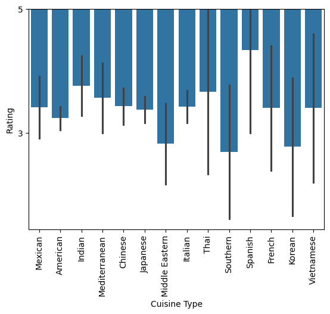

```python
rated_dist  = order[order['Rated'] == True]
sns.barplot(rated_dist,x="Cuisine Type",y="Rating")
plt.xticks(rotation=90)
plt.show()
```

I don't know how comfortable I feel with those IQRs.

```python
rated_dist.head()
```

|  | Customer ID | Restaurant Name | Cuisine Type | Cost Of The Order | Day Of The Week | Rating | Food Preparation Time | Delivery Time | Rated | Total Time | Customer Regularity | Cuisine Regularity | Restaurant Regularity | Average Bill | Average Restaurant Time |
| --- | --- | --- | --- | --- | --- | --- | --- | --- | --- | --- | --- | --- | --- | --- | --- |
| 2 | 66393 | Cafe Habana | Mexican | 12.23 | Weekday | 5 | 23 | 28 | True | 51.0 | 1.0 | 77.0 | 16.0 | 12.23 | 52.312500 |
| 3 | 106968 | Blue Ribbon Fried Chicken | American | 29.20 | Weekend | 3 | 25 | 15 | True | 40.0 | 2.0 | 584.0 | 96.0 | 18.99 | 51.343750 |
| 4 | 76942 | Dirty Bird to Go | American | 11.59 | Weekday | 4 | 25 | 24 | True | 49.0 | 3.0 | 584.0 | 4.0 | 17.67 | 48.000000 |
| 5 | 147468 | Tamarind TriBeCa | Indian | 25.22 | Weekday | 3 | 20 | 24 | True | 44.0 | 3.0 | 73.0 | 27.0 | 15.86 | 50.407407 |
| 7 | 89574 | Barbounia | Mediterranean | 5.97 | Weekday | 3 | 33 | 30 | True | 63.0 | 1.0 | 46.0 | 6.0 | 5.97 | 51.833333 |

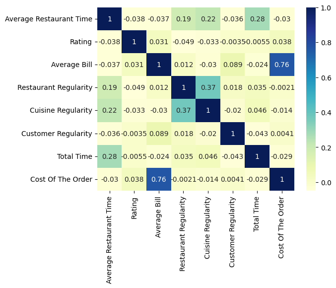

```python
def MrHeatMiser(MrSun):
  a = ['Average Restaurant Time','Rating','Average Bill','Restaurant Regularity','Cuisine Regularity','Customer Regularity','Total Time','Cost Of The Order']
  i = 0; trendy = pd.DataFrame()
  while i < len(a):
    trendy[a[i]] = MrSun[a[i]].rank(pct=True,method='average')
    i += 1
  trendy.head()
  return sns.heatmap(data=trendy[['Average Restaurant Time','Rating','Average Bill','Restaurant Regularity','Cuisine Regularity','Customer Regularity','Total Time','Cost Of The Order']].corr(), annot=True, cmap='YlGnBu');
MrHeatMiser(rated_dist)
```

#### Observations:

I've concluded that it is safe to assume that there is no significant correlation between the rating and any other figure by which to group the missing value.

As such, I will use the missing value from before to fill in every NaN value in the original data unless there is an average rating already established for the location (and I will get the already established average rating from the dictionary titled average_rating_of_the_restaurants).

```python
i = 0; rown,coln = order.shape;
k = order.columns.get_loc('Rating')
w = order.columns.get_loc('Restaurant Name')
while i < rown:
  j = order.iloc[i,k]
  if str(j) == 'Not given':
    if str(average_ratings_of_restaurants[order.iloc[i,w]]) == 'nan':
      order.iloc[i,k] = the_new_pi
    else:
      order.iloc[i,k] = average_ratings_of_restaurants[order.iloc[i,w]]
  else:
    0
  i += 1
order.head()
```

|  | Customer ID | Restaurant Name | Cuisine Type | Cost Of The Order | Day Of The Week | Rating | Food Preparation Time | Delivery Time | Rated | Total Time | Customer Regularity | Cuisine Regularity | Restaurant Regularity | Average Bill | Average Restaurant Time |
| --- | --- | --- | --- | --- | --- | --- | --- | --- | --- | --- | --- | --- | --- | --- | --- |
| 0 | 337525 | Hangawi | Korean | 30.75 | Weekend | 4.397807 | 25 | 20 | False | 45.0 | 2.0 | 13.0 | 2.0 | 31.985 | 44.000000 |
| 1 | 358141 | Blue Ribbon Sushi Izakaya | Japanese | 12.08 | Weekend | 4.333333 | 25 | 23 | False | 48.0 | 1.0 | 470.0 | 29.0 | 12.080 | 52.206897 |
| 2 | 66393 | Cafe Habana | Mexican | 12.23 | Weekday | 5 | 23 | 28 | True | 51.0 | 1.0 | 77.0 | 16.0 | 12.230 | 52.312500 |
| 3 | 106968 | Blue Ribbon Fried Chicken | American | 29.20 | Weekend | 3 | 25 | 15 | True | 40.0 | 2.0 | 584.0 | 96.0 | 18.990 | 51.343750 |
| 4 | 76942 | Dirty Bird to Go | American | 11.59 | Weekday | 4 | 25 | 24 | True | 49.0 | 3.0 | 584.0 | 4.0 | 17.670 | 48.000000 |

```python
k = original.columns.get_loc('Rating')
i =original.iloc[1,k]
average_ratings_of_restaurants[order.iloc[1,1]]
```

```
4.333333333333333
```

### **Question 4:**

What is the minimum, average, and maximum time it takes for food to be prepared once an order is placed?

```python
order.describe()
```

|  | Customer ID | Cost Of The Order | Food Preparation Time | Delivery Time | Total Time | Customer Regularity | Cuisine Regularity | Restaurant Regularity | Average Bill | Average Restaurant Time |
| --- | --- | --- | --- | --- | --- | --- | --- | --- | --- | --- |
| count | 1898.000000 | 1898.000000 | 1898.000000 | 1898.000000 | 1898.000000 | 1898.000000 | 1898.000000 | 1898.000000 | 1898.000000 | 1898.000000 |
| mean | 171168.478398 | 16.498851 | 27.371970 | 24.161749 | 51.533720 | 2.332982 | 376.236038 | 64.589041 | 16.498851 | 51.533720 |
| std | 113698.139743 | 7.483812 | 4.632481 | 4.972637 | 6.833603 | 1.840154 | 194.569701 | 68.295667 | 5.898358 | 2.202946 |
| min | 1311.000000 | 4.470000 | 20.000000 | 15.000000 | 35.000000 | 1.000000 | 7.000000 | 1.000000 | 4.750000 | 38.000000 |
| 25% | 77787.750000 | 12.080000 | 23.000000 | 20.000000 | 47.000000 | 1.000000 | 215.000000 | 13.000000 | 12.230000 | 50.565217 |
| 50% | 128600.000000 | 14.140000 | 27.000000 | 25.000000 | 52.000000 | 2.000000 | 470.000000 | 37.000000 | 15.800000 | 51.500000 |
| 75% | 270525.000000 | 22.297500 | 31.000000 | 28.000000 | 56.000000 | 3.000000 | 584.000000 | 96.000000 | 19.889167 | 52.607306 |
| max | 405334.000000 | 35.410000 | 35.000000 | 33.000000 | 68.000000 | 13.000000 | 584.000000 | 219.000000 | 33.320000 | 67.000000 |

```python
def ratatouille(anyone):
  print('The minimum amount of recordable time required to prepare an order has been', order[anyone].min(),'minutes.')
  a = round(order[anyone].mean())
  b = round((order[anyone].mean() - a)*60)
  if b < 0:
    a -= 1
    b += 60
  else:
    0
  print('The average time required to prepare the food is approximately', a, 'minutes and', b, 'seconds.')
  print('The maximum amount of recordable time required to prepare an order has been', order[anyone].max(),'minutes.')
ratatouille('Food Preparation Time')
```

```
The minimum amount of recordable time required to prepare an order has been 20 minutes.
The average time required to prepare the food is approximately 27 minutes and 22 seconds.
The maximum amount of recordable time required to prepare an order has been 35 minutes.
```

```python
ratatouille('Total Time')
```

```
The minimum amount of recordable time required to prepare an order has been 35.0 minutes.
The average time required to prepare the food is approximately 51 minutes and 32 seconds.
The maximum amount of recordable time required to prepare an order has been 68.0 minutes.
```

#### Observations:

According to the statistical summary of the data, the average time, minimum time, and maximum time that it takes for food to be prepared by restaurant is approximately 27.37 minutes, 20 minutes, and 35 minutes respectively. If we include the delivery time in those calculations, those figures come out to 51.53 minutes, 35 minutes, and 68 minutes respectively.

### **Question 5:**

How many orders are not rated?

```python
raters_of_the_lost_ark = rown - order['Rated'].sum()
print(raters_of_the_lost_ark,"of the orders are not rated.")
```

```
736 of the orders are not rated.
```

```python
print("The comes out to approximately ",round(raters_of_the_lost_ark/rown*100),"% of the orders.",sep='')
```

```
The comes out to approximately 39% of the orders.
```

#### Observations:

- 736 of the orders are not rated.
- The comes out to approximately 39% of the orders.

# **ACT III:** Exploratory Data Analysis (EDA)

### **Question 6:**

Explore all the variables and provide observations on their distributions.

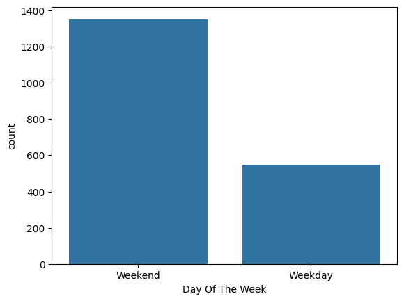

```python
sns.countplot(data=order, x="Day Of The Week")
plt.show()
```

Despite there being fewer weekend days than week days, there are far more orders made over the weekend.

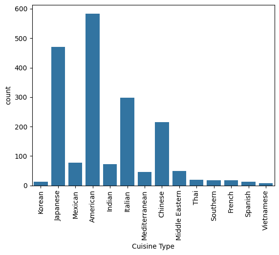

```python
sns.countplot(data=order, x="Cuisine Type")
plt.xticks(rotation=90)
plt.show()
```

The number of orders made for American, Japanese, Italian, and Chinese food is much larger than the number of orders made for most other forms of cuisine.

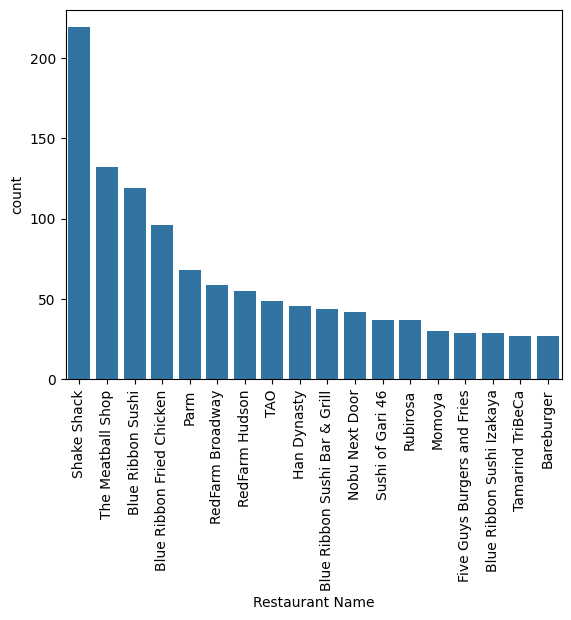

```python
df = pd.DataFrame(order['Restaurant Name'].value_counts().reset_index(name='count'))
df = df.rename(columns={'index': 'Restaurant Name'})
sns.barplot(data = df[df['count'] > 25], x = 'Restaurant Name', y = 'count')
plt.xticks(rotation=90)
plt.show()
```

The relationship between the number of orders from a restaurant and the inverse of the rank of that restaurant - where rank is a relative and linear measure of success - is inversely logarithmic.

This might be because of some technofeudal and potentially unethical conseqeunce of the alogrithms used by the app and laws used to influence the significance of real estate to the nature of competition; however, it might also be caused by nothing more than the social influence of being identified with the product.

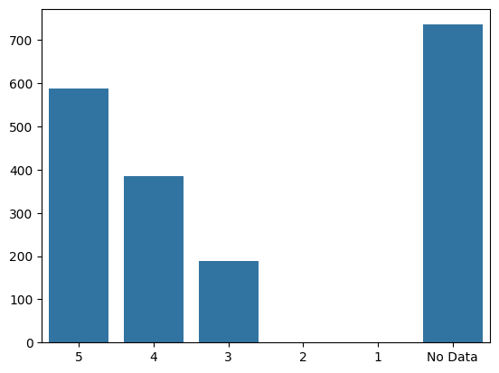

```python
i = 0; a = 0; b = 0; c = 0; d = 0; e = 0; f = 0;
while i < rown:
  if original.iloc[i,6] == "5":
    a += 1
  elif original.iloc[i,6] == "4":
    b += 1
  elif original.iloc[i,6] == "3":
    c += 1
  elif original.iloc[i,6] == "2":
    d += 1
  elif original.iloc[i,6] == "1":
    e += 1
  else:
    f += 1
  i += 1
display = {"5":a,"4":b,"3":c,"2":d,"1":e,"No Data":f}
sns.barplot(x=list(display.keys()),y=list(display.values()))
plt.show()
```

Oddly enough, there are no ratings lower than "3." As a human being and someone who admires the culture of New York, I'm not too too surprised, but it is still strange that out of nearly 2,000 orders, no such outliers were observed.

Less surprising is that the relationship between count and higher ratings is linear and positive; although, there are only three data points.

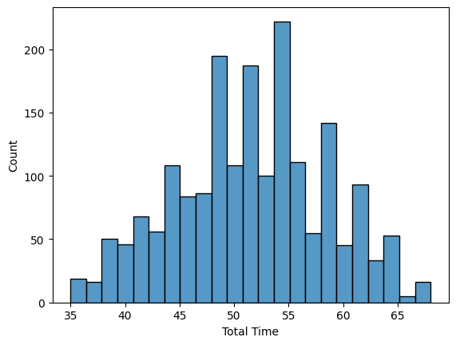

```python
if open == True:
  px.histogram(order, x="Total Time")
else:
  sns.histplot(data=order, x="Total Time")
```

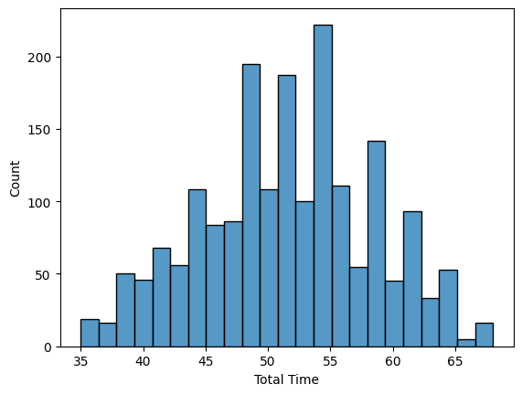

```python
if open == True:
  px.box(order, x="Total Time")
else:
  sns.histplot(data=order, x="Total Time")
```

The total time required for an order is fairly normal distribution if not slightly but not significantly wide. There are no outliers, which points to how competitive a business must be to have passed the tests of New York's commerical form of natural selection.

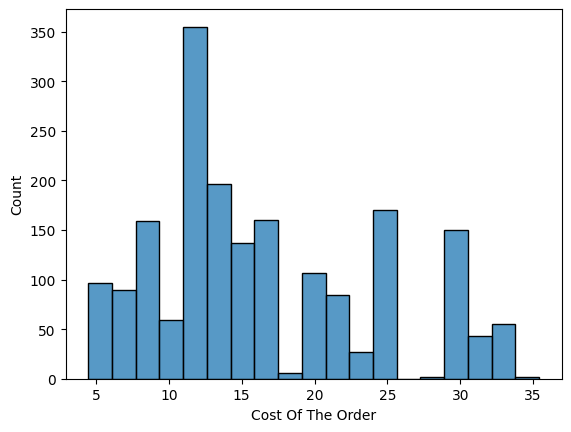

```python
if open == True:
  px.box(order, x="Cost Of The Order")
else:
  sns.histplot(data=order, x="Cost Of The Order")
```

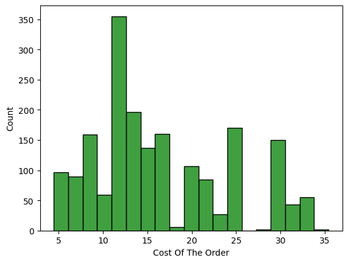

```python
if open == True:
  px.histogram(order, x="Cost Of The Order",  color_discrete_sequence=['green'])
else:
  sns.histplot(data=order, x="Cost Of The Order",  color='green')
```

The cost of the order is positively skewed, as should be expected when there is no food that is sold for less than $0, but the price of food can theoretically approach that of infinity.

$12.99 is a popular price for an order. This might be due to how much people can afford to pay, but it also might be due to how hard it is to compete with other restaurants who advertise to that same demographic of consumers.

Needless to say, it seems as though there is some good deal for a product that is around $13 that keeps customers returning for more, so this should likely be advertised to less exposed groups who may be unaware of an offer that seems to have consumer approval.

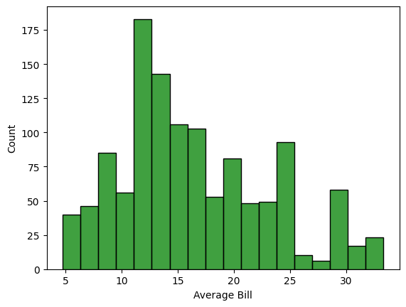

```python
golden_goose = rosebud(order,'Cost Of The Order','Customer ID','Mr. Thatcher')
df = pd.DataFrame(list(golden_goose.items()),columns = ['Customer ID','Average Bill'])
if open == True:
  px.histogram(df, x="Average Bill",  color_discrete_sequence=['green'])
else:
  sns.histplot(df, x="Average Bill",  color='green')
```

Perhaps this is because some customers are buying their favorite meal that they can only get delivered on this particular app or because of the deals that are offered by the app to remain competitive against other apps.

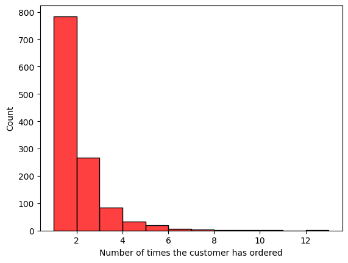

```python
i = 0; dic = {};
k = order.columns.get_loc('Customer ID')
while i < rown:
  if order.iloc[i,k] in dic:
    dic[order.iloc[i,k]] += 1
  else:
    dic[order.iloc[i,k]] = 1
  i += 1
peeps = pd.DataFrame(dic.values())
sns.histplot(data=peeps, x=0, color='red',bins=12)
plt.xlabel('Number of times the customer has ordered')
plt.show()
```

This graph represents exponential decay of the integrity seen of the service being provided by the app. Put simply, users are not returning at a rate far greater than a more idea, linear graph, and the costs of these losses are thus, exponential.

The company needs to do far more work to ensure that customers loyalty is retained, and there is so much potential for growth in that respect.

### **Question 7**:

Which are the top 5 restaurants in terms of the number of orders received?

```python
df = pd.DataFrame({'count':order['Restaurant Name'].value_counts()})
df.head()
```

| Restaurant Name | count |
| --- | --- |
| Shake Shack | 219 |
| The Meatball Shop | 132 |
| Blue Ribbon Sushi | 119 |
| Blue Ribbon Fried Chicken | 96 |
| Parm | 68 |

```python
def big_cheese(data,column,goal):
  i = 0;
  while len(data[data[column]>i]) > goal:
    i += 1
  if len(data[data[column]>i]) == goal:
    return data[data[column]>i]
  else:
    print('There was a tie between the lowest',len(data[data[column]>(i-1)])-len(data[data[column]>(i)]),"values.\nNevertheless!")
    return (data[data[column]>(i-1)])
print('The top 5 best sellers of this report were\n(Drumroll, please!) ...\n',big_cheese(df,'count',5).rename(columns={'count':'with this number of orders'}))
```

```
The top 5 best sellers of this report were
(Drumroll, please!) ...
                            with this number of orders
Restaurant Name
Shake Shack                                       219
The Meatball Shop                                 132
Blue Ribbon Sushi                                 119
Blue Ribbon Fried Chicken                          96
Parm                                               68
```

#### Observations:

The top 5 best sellers of this report were (Drumroll, please!) ...

1. Shake Shake with a total of 219 orders,
2. The Meatball Shop with a total of 132 orders,
3. Blue Ribbon Sushi with a total of 119 orders,
4. Blue Ribbon Fried Chicken with a total of 96 orders, and
5. Parm with a total of 68 orders!

### **Question 8**:

Which is the most popular cuisine on weekends?

```python
SNL = order.copy()
SNL = SNL.groupby('Day Of The Week')['Cuisine Type'].value_counts().drop('Weekday',axis = 0)
SNL = pd.DataFrame({'count':SNL})
SNL
```

| Day Of The Week | Cuisine Type | count |
| --- | --- | --- |
| Weekend | American | 415 |
|  | Japanese | 335 |
|  | Italian | 207 |
|  | Chinese | 163 |
|  | Mexican | 53 |
|  | Indian | 49 |
|  | Mediterranean | 32 |
|  | Middle Eastern | 32 |
|  | Thai | 15 |
|  | French | 13 |
|  | Korean | 11 |
|  | Southern | 11 |
|  | Spanish | 11 |
|  | Vietnamese | 4 |

```python
SNL = big_cheese(SNL,'count',1)
SNL
```

| Day Of The Week | Cuisine Type | count |
| --- | --- | --- |
| Weekend | American | 415 |

#### Observations:

American Food is the most common place to which orders are send, with a total of 415 of the orders coming from American food places.

However, a great number of these orders are likely individual orders to Shake Shack, so the question still remains: where and how are customers spending the most money?

### **Question 9**:

What percentage of the orders cost more than 20 dollars?

```python
i = 0; how = 0;
while i < rown:
  if order.iloc[i,3] > 20:
    how += 1
  else:
    0
  i += 1
  percentage = round(how/rown*100)
print(percentage,"% of the orders cost more than $20.",sep='')
```

```
29% of the orders cost more than $20.
```

#### Observations:

29% of the orders cost more than $20.

### **Question 10**:

What is the mean order delivery time?

```python
def franklin (sun):
  y = (int(sun))
  sun = sun - y
  sun = round(sun*60)
  return y,sun
a,b = franklin(order['Delivery Time'].mean())
c,d = franklin(order['Total Time'].mean())
print("The mean order delivery time is",a,"minutes and",b,"seconds.")
print("The mean total time taken to get an order is",c,"minutes and",d,"seconds.")
```

```
The mean order delivery time is 24 minutes and 10 seconds.
The mean total time taken to get an order is 51 minutes and 32 seconds.
```

#### Observations:

The mean order delivery time is approximately 24 minutes and 10 seconds.

However, if we were looking for the mean total time taken to get an order, that would be approximately 51 minutes and 32 seconds.

### **Question 11:**

The company has decided to give 20% discount vouchers to the top 3 most frequent customers. Find the IDs of these customers and the number of orders they placed.

```python
order['Customer ID'].value_counts().head(3)
```

| Customer ID | count |
| --- | --- |
| 52832 | 13 |
| 47440 | 10 |
| 83287 | 9 |

**dtype:** int64

```python
winners = order['Customer ID'].value_counts().head(3).to_dict()
a = order.groupby('Customer ID')['Average Bill'].mean().loc[list(winners.keys())].to_dict().values()
a = np.array(list(a)).sum()
print("This promotion would cost the company $",round(a*0.2,2),sep='')
```

```
This promotion would cost the company $9.73
```

#### Observations:

The customers with IDs of 52832, 47440, and 83287 were the most frequent users.

This promotion is a splendid idea, especially because it may only cost the company $9.73 if the offer were to provide them with something that is within their average spending price, and because it is in their average spending price, it is likely something that they would be very happy with and that they actually want while also enjoying the discount.

# **ACT IV:** Multivariate Analysis

### **Question 12**:

Perform a multivariate analysis to explore relationships between the important variables in the dataset.

To begin, let's look back at that heatmap from earlier - when I had compared the rank of values within a dataset to the rank of the other values in their row:

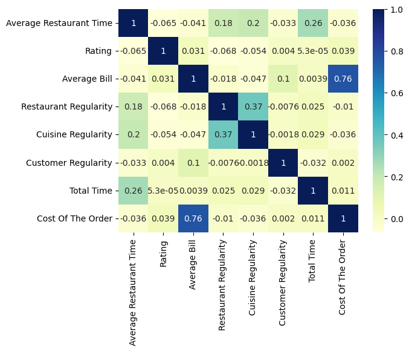

```python
MrSnow = order.copy()
i = 0; rown,coln = MrSnow.shape; j = MrSnow.columns.get_loc('Rating');
while i < rown:
  if type(MrSnow.iloc[i,j]) == str:
    MrSnow.iloc[i,j] = float(MrSnow.iloc[i,j])
  elif type(MrSnow.iloc[i,j]) == int:
    MrSnow.iloc[i,j] = float(MrSnow.iloc[i,j])
  else:
    0
  i += 1
MrHeatMiser(MrSnow)
```

The most remarkable thing about this heatmap is how little of a correlation it reveals.

This begs the question: what happens when I drop the that great myriad of single purchases to learn more about the class of users who are returning customers.

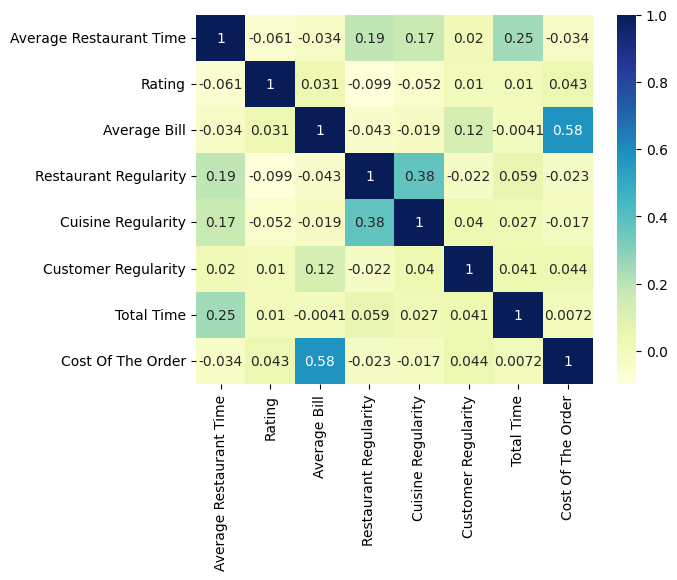

```python
frosty = MrSnow[MrSnow['Customer Regularity'] >= 2].copy()
MrHeatMiser(frosty)
```

It seems that there is nothing that is very out of the ordinary to be said about the different in heatmaps of those with more or less orders other than the averages were affects - though we didn't need the data to know that a/a has less variability than 2a/(a+b), as in the case of finding the average of two variables rather than just find the average of one while comparing it to some random sample of behind the average.

```python
sns.pairplot(data=MrSnow, hue='Day Of The Week')
```

[output not shown]

The obvious next place to look would be at the ratings associated with any of these trends; however, we have already discussed the existential conundrums surrounding non-objective data, but it would hurt to explore. But first things first, for the purposes of the questions I'm asking, I do not want to be tricked by my own biases as someone wanting lots of data that doesn't actually exist. And with how much data contained in the data set, the sample size is large enough to start taking the qualifications seriously, so let's take out all of the data that doesn't exactly represent the cold, hard truth of the matter being explored. Let's take out all of the rows without ratings and see if we can find trends in the rating data.

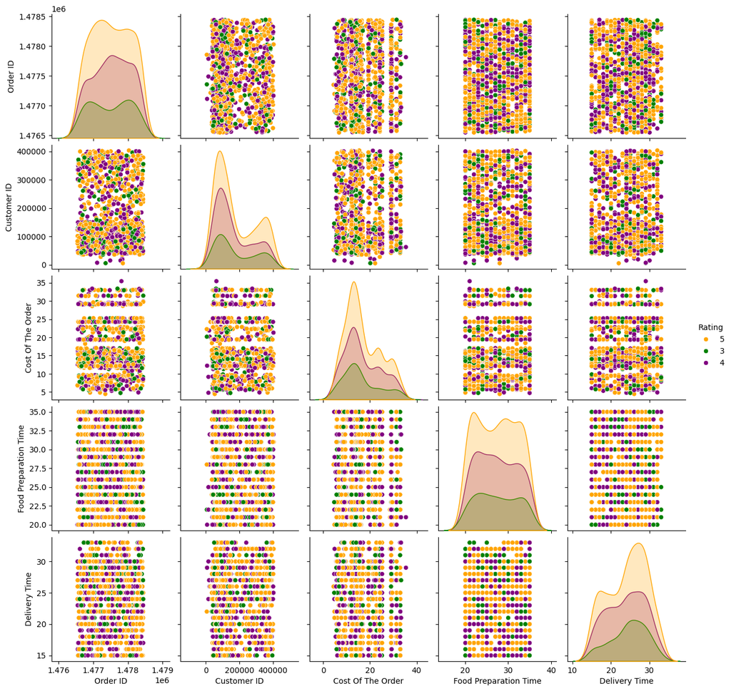

```python
i = 0; rown,coln = original.shape;
frosthe = original.copy(); k = frosthe.columns.get_loc('Rating'); j=0;
while i < (rown - original.groupby('Rating').count().to_dict()['Customer ID']['Not given']):
  if frosthe.iloc[i,k] == 'Not given':
    frosthe = frosthe.drop(i+j)
    j +=1
  else:
    i += 1
frosthe = frosthe.drop(i+j)
sns.pairplot(data=frosthe, hue='Rating',palette=['orange','green','purple'])
```

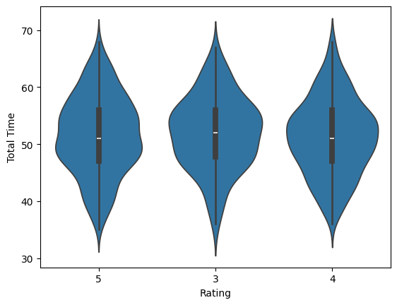

```python
frosthe['Total Time'] = frosthe['Delivery Time'] + frosthe['Food Preparation Time']
frosthe = frosthe.reset_index(drop=True)
sns.violinplot(data=frosthe, y='Total Time', x='Rating')
```

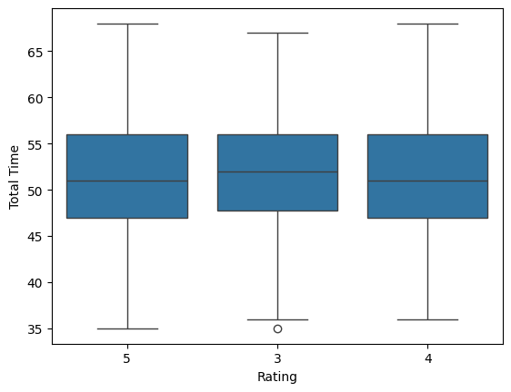

```python
sns.boxplot(data=frosthe, x='Rating', y='Total Time')
```

It seems as though the amount of time that it takes for the food to be delivered does not have a significant impact on the ratings given.

Therefore, I can sleep easy at night knowing that my degree in Philosophy wasn't completely useless because I was able to make that predicion prior to spending these efforts on the analysis.

Now, let's think about what is going on with some of the trends that can be made out from the pairplot from earlier:

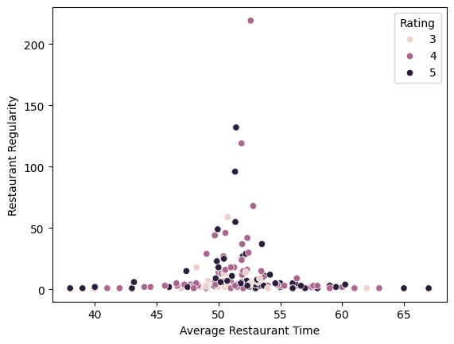

```python
threeD = order.copy(); i = 0; k = order.columns.get_loc('Rating'); rown,coln = threeD.shape;
while i < rown:
    threeD.iloc[i,k] = (int(threeD.iloc[i,k]))
    i += 1
if open == True:
  fig = px.scatter_3d(threeD, x='Restaurant Regularity', y='Cuisine Regulariy', z='Average Restaurant Time', color='Rating')
  fig.show()
else:
  sns.scatterplot(data=threeD, y='Restaurant Regularity', x='Average Restaurant Time', hue='Rating')
  plt.show()
```

It might be worth thinking about how the lowest scores are by customers who are not represented by the more outlying data. This may be hard to interpret with graphs rather than numbers (and in case you couldn't tell, especially as a Physicist, I tend to prefer numbers to visual), but perhaps this can be explained by the circumstances surrounding that caused the delays: somebody is ording during a holiday, during a blizzard, first thing in the morning, or right before the restaurant is about to close.

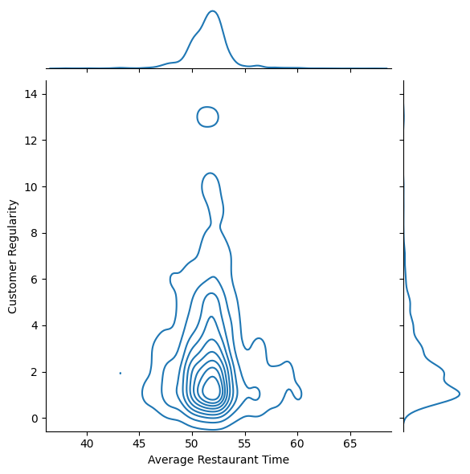

```python
sns.jointplot(data=MrSnow,y='Customer Regularity',x='Average Restaurant Time',kind='kde')
```

It shouldn't be a surprise that the restaurants in New York don't treat have the app users who regularly use the app with service that is any faster or slower than any other. In the case of the kde joint plot above, the rare few who are regulars are just as likely to end up at the center circle as those who fall lower on the line. However, it does seem that restaurants that are more have more predictable preperation times might attract some cohort of consumers which have branched off to for star, high up above the tree like structure of the kde jointplot.

```python
sns.pairplot(data=threeD,hue='Rating',palette=['orange','green','purple'])
```

[output not shown]

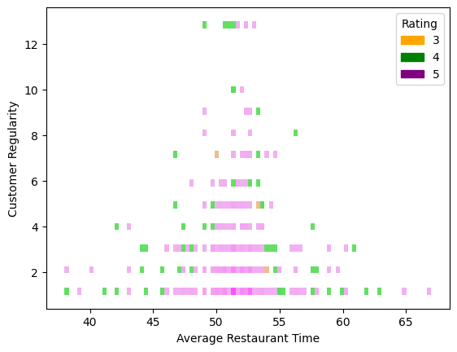

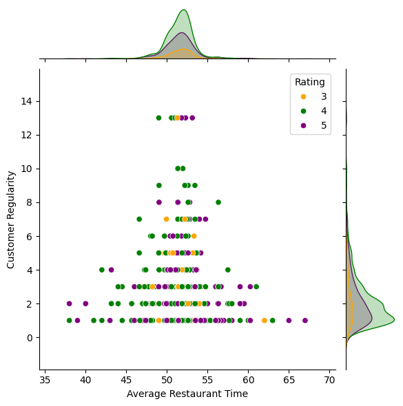

```python
sns.histplot(data=threeD,y='Customer Regularity',x='Average Restaurant Time',hue='Rating',palette=['orange','green','purple'])
sns.jointplot(data=threeD,y='Customer Regularity',x='Average Restaurant Time',hue='Rating',palette=['orange','green','purple'])
```

And at long last, amongst the rubble of data points piled upon datapoint, a small nugget of transparency rises from the ashed. I include both of these graphs so that it is clear that there are some 3 data point tucked away in there - which should be an obvious fact. But the histogram points to the appreciation of consistency amongst the most opinionated of users.

And now, to get at the heart of the company's regular customers:

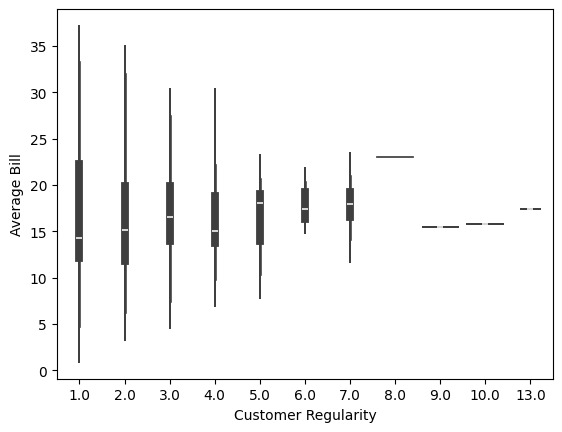

```python
sns.violinplot(data=order, y='Average Bill', x='Customer Regularity')
```

It seems as though the regular users tend to spend a far more predictable amount. While these figures may be biased by the quantity of custmers expressed by each boxplot, there is nevertheless a trend, a trend that has not been offset by some outliers.

Moreover, if we take into account how the returning customer may spend less than the occassional caterors and buffet-in-bed-even-though-I-can't-cook-romantics, when we multipy their numbers by how often they spend, they are the primary consumer upon which this company depends most.

### **Question 13:**

The company wants to provide a promotional offer in the advertisement of the restaurants. The condition to get the offer is that the restaurants must have a rating count of more than 50 and the average rating should be greater than 4. Find the restaurants fulfilling the criteria to get the promotional offer.

```python
RatedRestaurants = original[original['Rating'] != 'Not given'].copy()
RatedRestaurants['Rating'] = RatedRestaurants['Rating'].astype('int')
RatedRestaurants = RatedRestaurants.groupby(['Restaurant Name'])['Rating'].count()
i = 0; j = 0; rownRR = RatedRestaurants.count();
while j < rownRR:
  if RatedRestaurants.iloc[i] < 50:
    RatedRestaurants = RatedRestaurants.drop(RatedRestaurants.index[i])
  else:
    i += 1
  j += 1
print('There are',RatedRestaurants.count(),'restaurants with more than 50 ratings.')
RatedRestaurants.head()
```

```
There are 4 restaurants with more than 50 ratings.
```

| Restaurant Name | Rating |
| --- | --- |
| Blue Ribbon Fried Chicken | 64 |
| Blue Ribbon Sushi | 73 |
| Shake Shack | 133 |
| The Meatball Shop | 84 |

**dtype:** int64

```python
RestaurantRatings = original[original['Rating'] != 'Not given'].copy()
RestaurantRatings['Rating'] = RestaurantRatings['Rating'].astype('int')
RestaurantRatings = RestaurantRatings[RestaurantRatings['Restaurant Name'].isin(RatedRestaurants.index)]
RestaurantRatings = RestaurantRatings.groupby(['Restaurant Name'])['Rating'].mean()
RestaurantRatings.head()
```

| Restaurant Name | Rating |
| --- | --- |
| Blue Ribbon Fried Chicken | 4.328125 |
| Blue Ribbon Sushi | 4.219178 |
| Shake Shack | 4.278195 |
| The Meatball Shop | 4.511905 |

**dtype:** float64

### **Question 14:**

The company charges the restaurant 25% on the orders having cost greater than 20 dollars and 15% on the orders having cost greater than 5 dollars. Find the net revenue generated by the company across all orders.

```python
i = 0; how = 0;
while i < rown:
  if order.iloc[i,3] > 20:
    how += order.iloc[i,3]*0.25
  elif order.iloc[i,3] > 5:
    how += order.iloc[i,3]*0.15
  else:
    0
  i += 1
g = str(round(how*100))
print("The net revenue generated by the company across all orders is $",g[:-2]+'.'+g[-2:],".",sep='')
```

```
The net revenue generated by the company across all orders is $6166.30.
```

### **Question 15:**

The company wants to analyze the total time required to deliver the food. What percentage of orders take more than 60 minutes to get delivered from the time the order is placed? (The food has to be prepared and then delivered.)

```python
i = 0; how = 0;
while i < rown:
  if order.iloc[i,6] + order.iloc[i,7] > 60:
    how += 1
  else:
    0
  i += 1
fast = round(how/rown*100,3)
print("Only ",fast,"% of the orders take more than 60 minutes to get delivered.",sep='')
```

```
Only 10.537% of the orders take more than 60 minutes to get delivered.
```

#### Observations:

Approximatly 10.537% of the orders take more than 60 minutes to get delivered; however, if we were to round this up, it would unfortunately come up to a solid 11%.

Perhaps this is why the app is not more popular than it could be amongst the New Yorkers.

### **Question 16:**

The company wants to analyze the delivery time of the orders on weekdays and weekends. How does the mean delivery time vary during weekdays and weekends?

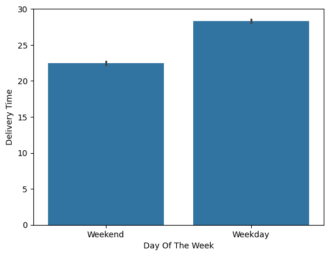

```python
Q16 = original.copy()
numbers = Q16.groupby('Day Of The Week')['Delivery Time'].mean().to_dict()
sns.barplot(data=Q16, x="Day Of The Week", y="Delivery Time")
plt.show()
```

```python
def taco_tuesday(numbers):
  a = numbers['Weekday']
  b = numbers['Weekend']
  a,b = franklin(a - b)
  print("The delivery process on a weekday tends to take",a,'minues and',b,'seconds longer.')
taco_tuesday(numbers)
```

```
The delivery process on a weekday tends to take 5 minues and 52 seconds longer.
```

#### Observations:

More specifically, The delivery process on a weekday tends to take 5 minues and 52 seconds longer.

Perhaps there are far fewer deliveries on weekdays because of how long it takes people to get their food?

```
{'Weekday': 55.552102376599635, 'Weekend': 49.90673575129534}
```

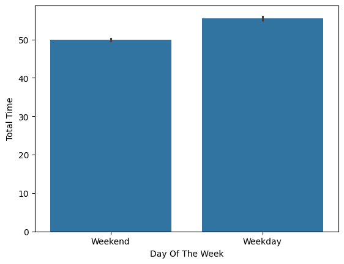

```python
Q17 = order.copy()
numbers = Q17.groupby('Day Of The Week')['Total Time'].mean().to_dict()
print(str(numbers))
sns.barplot(data=Q17, x="Day Of The Week", y="Total Time")
plt.show()
```

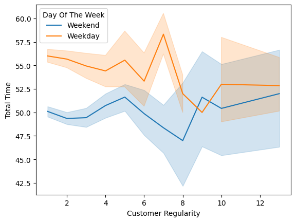

```python
sns.lineplot(data=order, y="Total Time", x="Customer Regularity", hue='Day Of The Week')
```

```python
taco_tuesday(numbers)
```

```
The delivery process on a weekday tends to take 5 minues and 39 seconds longer.
```

### Conclusion and Recommendations

The two graphs above suggest that total amount of time taken to get the food after the deliver has been made is hardly significant - that is, assuming it isn't thatbig of a deal to wait an extra five minutes for food after having waited an entire hour.

Another thing to consider is how many orders are being place on the weekend which may cause the success of the business to jeapordize the efficiency of the service itself.

This last graph allows me to then present the case that perhaps the returning customers are more familar with the trends, the rush hours, the likelihood of enough people working, and whatever else the real factors are in determining the likely amount of time that it will take for the food to be delivered. Perhaps this is a reflection of where these customers live in the city or a reflection fo which of the three meals that they tend to use the app for.  
However, if this is this case, it is worth considering if this is the reason that some people are more likely to reuse the app relative to the ones who get the type of service that makes them want to reuse the app.

# **ACT V:** Adios

### **Question 17:**

What are my conclusions from the analysis, and what recommendations would you like to share to help improve the business: cuisine type and feedback ratings to drive business recommendations.

### Conclusions:

The primary conclusions that I have made are that

1. The rating system does not translate into any universal system of meaning; however, the belief in the rating system might inspire people to reuse the app.
2. American is very popular with New Yorkers, particularly, Shake Shack - despite and perhaps because of how cheap it is.
3. It is very rare that curstomers leave a bad review, so the few that are recieved should be treated with caution - as potential outliers - as well as with some degree of curiousity in order to maintain the social capital of being identified with the company.
4. Saving time on deivery is not an insignificant goal; however, it is not the primary problem faced by the company. The company should put more of the energy towards normalizing the use of the app.

```python
import time
time.sleep(120)
!jupyter nbconvert --to html '/content/drive/MyDrive/Data Analytics/Python/Python Fundamentals Project.ipynb' --output-dir '/content/drive/MyDrive/Data Analytics/Portfolio.html'
```

[output not shown]

# **Post Credit Scene**

**JO:** And now, to rap this baby up with a brief recap of The Great Russian Novelest and the intersections between their works and the contributions of Moby Dick to the humanities which have grown to justify the sociopolitical structures of New York's business and commerce.

**JACK:** Wait, are you talking to me? How long have you been talking? What's going on?

**JO:** Oh no. I'm just getting ready to knock this assinment out of the park in the only way I know how.

**JACK:** Are you talking about your math class?

**JO:** Well yes, but don't you see, everything is related to everything. We are swimming in an interconnected web of information, and mathematical expressions are just the beginnning of understanding it! It's beautiful! We're alive!

**JACK:** Yeah, but the class is literally called "Math." Right?

**JO:** Okay, yes. Technically, it is a "math" class, but they're going to get a kick out of my commentary on the rise of post-structuralism, the dawn of modernity, and all the implied parallels. Ah! *Parallels!* You see that. I'm already getting better at math! I guess I am learning something.

**JACK:** Jo. Put down the pen.

**JO:** But you haven't even read it yet.

**JACK:** You want me to read that? Me? Why?

**JO:** For the plot.

**JACK:** Just pick up an abacus; the world isn't going to math itself.

**JO:** But I'm just about to get to the good part.

**JACK:** Jo! Tomorrow.

**JACK:** Well, I do love a good cliffhanger.